# Tugas_P2_Nandito Hernawan

2025-08-26

```r
library("forecast")
```

```r
library("graphics")
library("TTR")
library("TSA")
library("rio")
```

# Input Data

```r
library(readxl)
data <- read_excel("C:/Users/LENOVO/Downloads/Data_MPDW1.xlsx")
data
```

```
## # A tibble: 200 × 2
##    Date                AI_Revenue_USD_Mn
##    <dttm>                          <dbl>
##  1 2023-11-28 00:00:00              128.
##  2 2023-11-29 00:00:00              129.
##  3 2023-11-30 00:00:00              129.
##  4 2023-12-01 00:00:00              129.
##  5 2023-12-02 00:00:00              129.
##  6 2023-12-03 00:00:00              129.
##  7 2023-12-04 00:00:00              129.
##  8 2023-12-05 00:00:00              129.
##  9 2023-12-06 00:00:00              129.
## 10 2023-12-07 00:00:00              129.
## # ℹ 190 more rows
```

# Eksplorasi Data

```r
View(data)
str(data)
```

```
## tibble [200 × 2] (S3: tbl_df/tbl/data.frame)
##  $ Date             : POSIXct[1:200], format: "2023-11-28" "2023-11-29" ...
##  $ AI_Revenue_USD_Mn: num [1:200] 128 129 129 129 129 ...
```

```r
dim(data)
```

```
## [1] 200   2
```

```r
data.ts <- ts(data$AI_Revenue_USD_Mn)
```

Menampilkan ringkasan data

```r
summary(data.ts)
```

```
##    Min. 1st Qu.  Median    Mean 3rd Qu.    Max.
##   128.2   153.9   154.6   150.4   155.0   156.0
```

Membuat plot data deret waktu

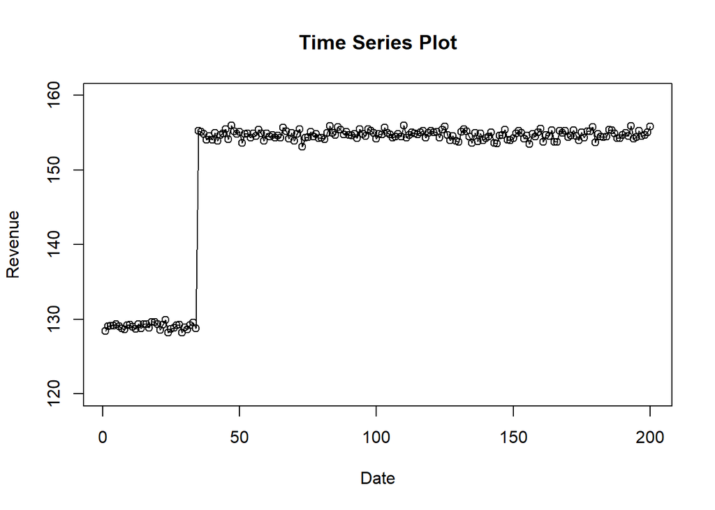

```r
ts.plot(data.ts, xlab = "Date", ylab = "Revenue",
        main = "Time Series Plot",
        ylim = c(120, 160))   # atur rentang Y
points(data.ts)
```

karena terdapat nilai ekstrim pada data, maka dilakukan pemotongan data dengan menghilangkan data pada tahun 2023 dan dimulai pada tahun 2024

```r
# Ubah kolom pertama jadi tipe Date
data$Date <- as.Date(data$Date)

# Ambil hanya data tahun 2024
data_2024 <- subset(data, format(Date, "%Y") == "2024")
data1 <- data_2024
data1
```

```
## # A tibble: 166 × 2
##    Date       AI_Revenue_USD_Mn
##    <date>                 <dbl>
##  1 2024-01-01              155.
##  2 2024-01-02              155.
##  3 2024-01-03              155.
##  4 2024-01-04              154.
##  5 2024-01-05              155.
##  6 2024-01-06              154.
##  7 2024-01-07              155.
##  8 2024-01-08              154.
##  9 2024-01-09              155.
## 10 2024-01-10              155.
## # ℹ 156 more rows
```

```r
data.ts <- ts(data1$AI_Revenue_USD_Mn)
```

```r
summary(data.ts)
```

```
##    Min. 1st Qu.  Median    Mean 3rd Qu.    Max.
##   153.1   154.3   154.8   154.7   155.1   156.0
```

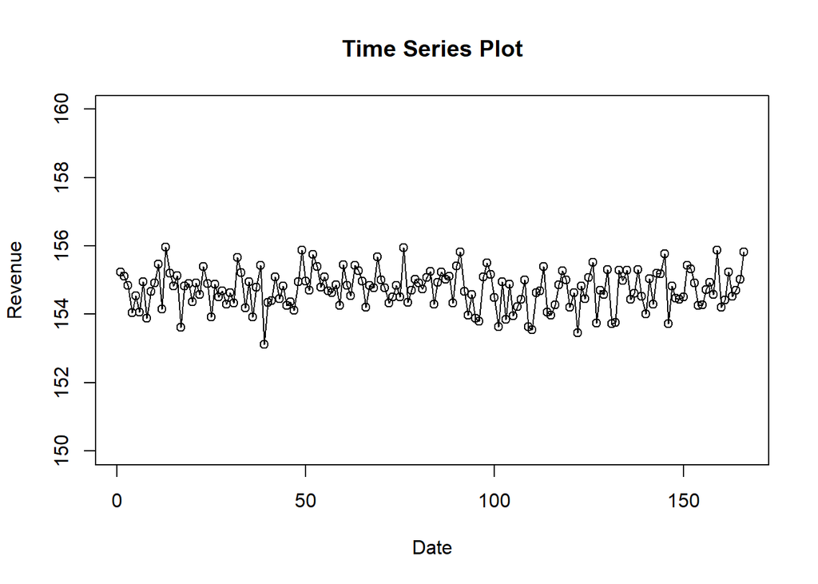

```r
ts.plot(data.ts, xlab = "Date", ylab = "Revenue",
        main = "Time Series Plot",
        ylim = c(150, 160))   # atur rentang Y
points(data.ts)
```

# Smoothing Data

## SMA (Single Moving Average)

```r
# hitung jumlah data
n <- nrow(data1)

# tentukan batas 80%
n_train <- floor(0.8 * n)

# bagi data
training_ma <- data1[1:n_train, ]
testing_ma  <- data1[(n_train+1):n, ]

# ubah ke time series
train_ma.ts <- ts(training_ma$AI_Revenue_USD_Mn)
test_ma.ts  <- ts(testing_ma$AI_Revenue_USD_Mn)
```

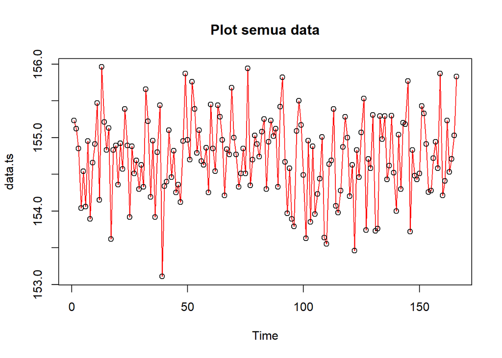

```r
plot(data.ts, col="red",main="Plot semua data")
points(data.ts)
```

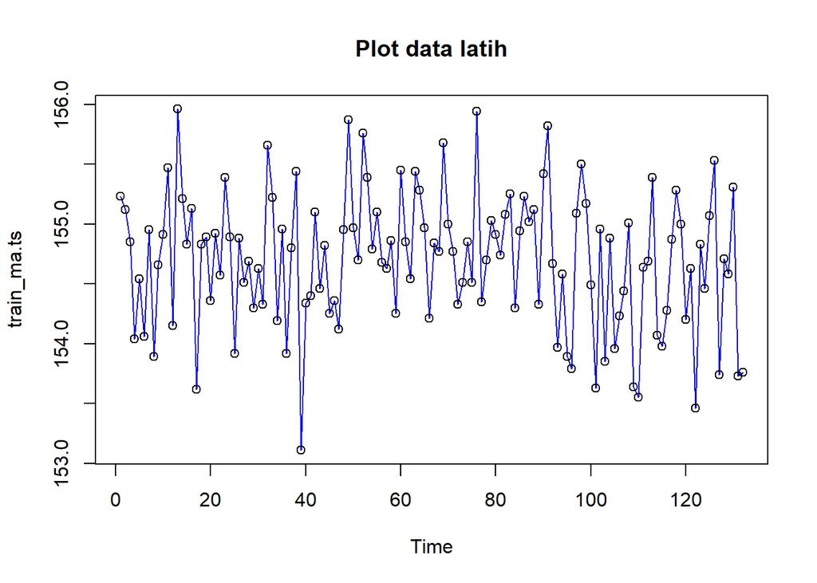

```r
plot(train_ma.ts, col="blue",main="Plot data latih")
points(train_ma.ts)
```

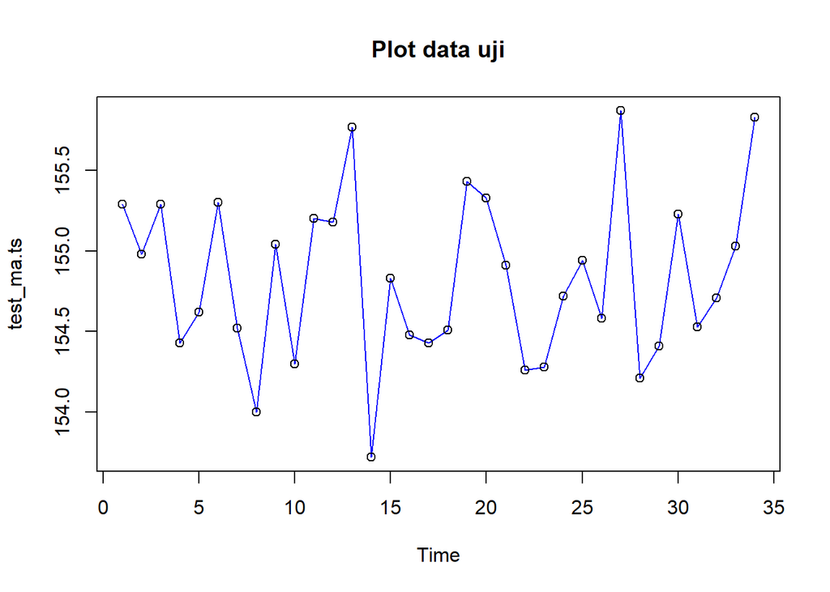

```r
plot(test_ma.ts, col="blue",main="Plot data uji")
points(test_ma.ts)
```

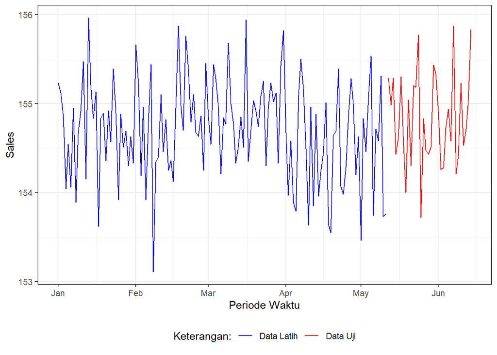

```r
library(ggplot2)
ggplot() +
  geom_line(data = training_ma, aes(x = Date, y = AI_Revenue_USD_Mn, col = "Data Latih")) +
  geom_line(data = testing_ma, aes(x = Date, y = AI_Revenue_USD_Mn, col = "Data Uji")) +
  labs(x = "Periode Waktu", y = "Sales", color = "Legend") +
   scale_colour_manual(name="Keterangan:", breaks = c("Data Latih", "Data Uji"),
                      values = c("blue", "red")) +
  theme_bw() + theme(legend.position = "bottom",
                     plot.caption = element_text(hjust=0.5, size=12))
```

```r
#Menghitung nilai keakuratan data latih
data.sma<-SMA(train_ma.ts, n=4)
data.sma
```

```
## Time Series:
## Start = 1
## End = 132
## Frequency = 1
##   [1]       NA       NA       NA 154.8100 154.6375 154.3725 154.3975 154.3600
##   [9] 154.3900 154.6025 154.7325 154.7975 155.1225 155.1975 155.0375 155.2825
##  [17] 154.6975 154.6025 154.6175 154.4250 154.7500 154.6850 154.8100 154.9425
##  [25] 154.6925 154.7700 154.5500 154.5000 154.5950 154.5325 154.4875 154.7300
##  [33] 154.9600 154.8500 155.0075 154.5725 154.4675 154.7800 154.3175 154.4225
##  [41] 154.3225 154.2375 154.5750 154.6950 154.6575 154.4725 154.3875 154.4200
##  [49] 154.8250 154.9775 155.1225 155.3250 155.2050 155.1600 155.2600 154.9900
##  [57] 154.8000 154.8175 154.6050 154.7975 154.8525 154.7725 155.0700 155.0275
##  [65] 155.0575 154.9750 154.8250 154.6975 154.8750 155.0725 155.0550 154.9450
##  [73] 154.6525 154.6150 154.5500 154.9525 154.9125 154.8750 155.0050 154.7475
##  [81] 154.8450 154.9400 154.9950 154.8425 154.8925 154.9300 154.8725 155.0775
##  [89] 154.9250 154.9725 155.1725 155.0600 154.9700 154.7600 154.2775 154.0575
##  [97] 154.3375 154.5675 154.8875 155.0625 154.6975 154.5625 154.2325 154.3300
## [105] 154.4125 154.2300 154.3775 154.4100 154.3300 154.1600 154.2100 154.1300
## [113] 154.5675 154.6975 154.5325 154.4300 154.3000 154.6025 154.8575 154.8375
## [121] 154.7775 154.3225 154.2800 154.3450 154.4550 154.9725 154.7000 154.7625
## [129] 154.6400 154.5850 154.5825 154.3450
```

```r
data.ramal<-c(NA,data.sma)
data.ramal #forecast 1 periode ke depan
```

```
##   [1]       NA       NA       NA       NA 154.8100 154.6375 154.3725 154.3975
##   [9] 154.3600 154.3900 154.6025 154.7325 154.7975 155.1225 155.1975 155.0375
##  [17] 155.2825 154.6975 154.6025 154.6175 154.4250 154.7500 154.6850 154.8100
##  [25] 154.9425 154.6925 154.7700 154.5500 154.5000 154.5950 154.5325 154.4875
##  [33] 154.7300 154.9600 154.8500 155.0075 154.5725 154.4675 154.7800 154.3175
##  [41] 154.4225 154.3225 154.2375 154.5750 154.6950 154.6575 154.4725 154.3875
##  [49] 154.4200 154.8250 154.9775 155.1225 155.3250 155.2050 155.1600 155.2600
##  [57] 154.9900 154.8000 154.8175 154.6050 154.7975 154.8525 154.7725 155.0700
##  [65] 155.0275 155.0575 154.9750 154.8250 154.6975 154.8750 155.0725 155.0550
##  [73] 154.9450 154.6525 154.6150 154.5500 154.9525 154.9125 154.8750 155.0050
##  [81] 154.7475 154.8450 154.9400 154.9950 154.8425 154.8925 154.9300 154.8725
##  [89] 155.0775 154.9250 154.9725 155.1725 155.0600 154.9700 154.7600 154.2775
##  [97] 154.0575 154.3375 154.5675 154.8875 155.0625 154.6975 154.5625 154.2325
## [105] 154.3300 154.4125 154.2300 154.3775 154.4100 154.3300 154.1600 154.2100
## [113] 154.1300 154.5675 154.6975 154.5325 154.4300 154.3000 154.6025 154.8575
## [121] 154.8375 154.7775 154.3225 154.2800 154.3450 154.4550 154.9725 154.7000
## [129] 154.7625 154.6400 154.5850 154.5825 154.3450
```

```r
data.gab<-cbind(
  aktual=c(data.ts),
  pemulusan=c(data.sma,rep(NA,33)),
  ramalan=c(data.ramal,rep(data.ramal[length(data.ramal)],32)))
data.gab #forecast 24 periode ke depan
```

```
##        aktual pemulusan  ramalan
##   [1,] 155.23        NA       NA
##   [2,] 155.12        NA       NA
##   [3,] 154.85        NA       NA
##   [4,] 154.04  154.8100       NA
##   [5,] 154.54  154.6375 154.8100
##   [6,] 154.06  154.3725 154.6375
##   [7,] 154.95  154.3975 154.3725
##   [8,] 153.89  154.3600 154.3975
##   [9,] 154.66  154.3900 154.3600
##  [10,] 154.91  154.6025 154.3900
##  [11,] 155.47  154.7325 154.6025
##  [12,] 154.15  154.7975 154.7325
##  [13,] 155.96  155.1225 154.7975
##  [14,] 155.21  155.1975 155.1225
```

[output cut: 152 more lines]

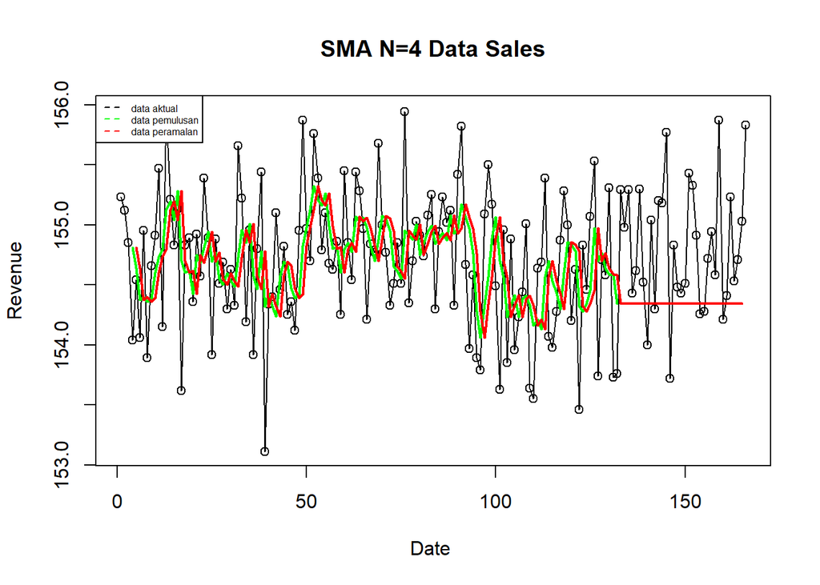

```r
ts.plot(data.ts, xlab="Date ", ylab="Revenue", main= "SMA N=4 Data Sales")
points(data.ts)
lines(data.gab[,2],col="green",lwd=2)
lines(data.gab[,3],col="red",lwd=2)
legend("topleft",c("data aktual","data pemulusan","data peramalan"), lty=8, col=c("black","green","red"), cex=0.5)
```

```r
#Menghitung nilai keakuratan data latih
error_train.sma = train_ma.ts-data.ramal[1:length(train_ma.ts)]

SSE_train.sma = sum(error_train.sma[5:length(train_ma.ts)]^2)
MSE_train.sma = mean(error_train.sma[5:length(train_ma.ts)]^2)
MAPE_train.sma = mean(abs((error_train.sma[5:length(train_ma.ts)]/train_ma.ts[5:length(train_ma.ts)])*100))

akurasi_train.sma <- matrix(c(SSE_train.sma, MSE_train.sma, MAPE_train.sma))
row.names(akurasi_train.sma)<- c("SSE", "MSE", "MAPE")
colnames(akurasi_train.sma) <- c("Akurasi m = 4")
akurasi_train.sma
```

```
##      Akurasi m = 4
## SSE     51.8973563
## MSE      0.4054481
## MAPE     0.3279922
```

Dalam hal ini nilai MAPE data latih pada metode pemulusan SMA sekitar 0,3%, nilai ini dapat dikategorikan sebagai nilai akurasi yang sangat baik. Selanjutnya dilakukan perhitungan nilai MAPE data uji pada metode pemulusan SMA.

```r
#Menghitung nilai keakuratan data uji
error_test.sma = test_ma.ts-data.gab[132.8:166,3]

SSE_test.sma = sum(error_test.sma^2)
MSE_test.sma = mean(error_test.sma^2)
MAPE_test.sma = mean(abs((error_test.sma/test_ma.ts*100)))

akurasi_test.sma <- matrix(c(SSE_test.sma, MSE_test.sma, MAPE_test.sma))
row.names(akurasi_test.sma)<- c("SSE", "MSE", "MAPE")
colnames(akurasi_test.sma) <- c("Akurasi m = 4")
akurasi_test.sma
```

```
##      Akurasi m = 4
## SSE     16.5649812
## MSE      0.4872053
## MAPE     0.3561893
```

## SES (Single Exponential Smoothing)

```r
# jumlah baris data
n <- nrow(data1)

# hitung batas 80%
n_train <- floor(0.8 * n)

# bagi data
training <- data1[1:n_train, ]
testing  <- data1[(n_train+1):n, ]

# ubah ke time series
train.ts <- ts(training$AI_Revenue_USD_Mn)
test.ts  <- ts(testing$AI_Revenue_USD_Mn)
```

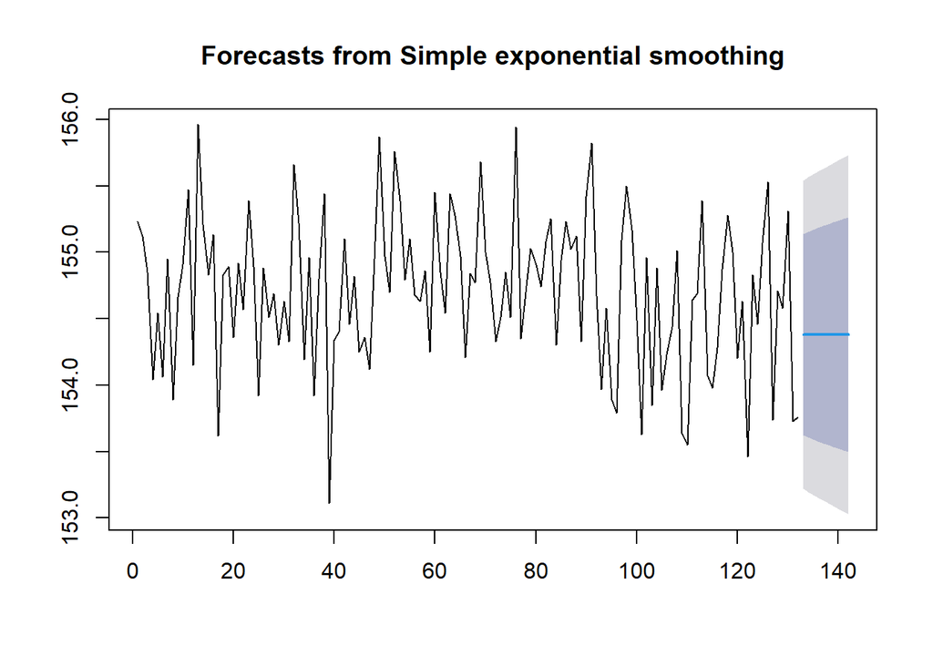

```r
#Cara 1 (fungsi ses)
ses.1 <- ses(train.ts, h = 10, alpha = 0.2)
plot(ses.1)
```

```r
ses.1
```

```
##     Point Forecast    Lo 80    Hi 80    Lo 95    Hi 95
## 133       154.3801 153.6213 155.1388 153.2196 155.5405
## 134       154.3801 153.6063 155.1538 153.1967 155.5635
## 135       154.3801 153.5915 155.1686 153.1741 155.5860
## 136       154.3801 153.5771 155.1830 153.1520 155.6081
## 137       154.3801 153.5629 155.1973 153.1303 155.6299
## 138       154.3801 153.5489 155.2112 153.1089 155.6512
## 139       154.3801 153.5351 155.2250 153.0879 155.6722
## 140       154.3801 153.5216 155.2385 153.0672 155.6929
## 141       154.3801 153.5083 155.2518 153.0468 155.7133
## 142       154.3801 153.4952 155.2649 153.0268 155.7333
```

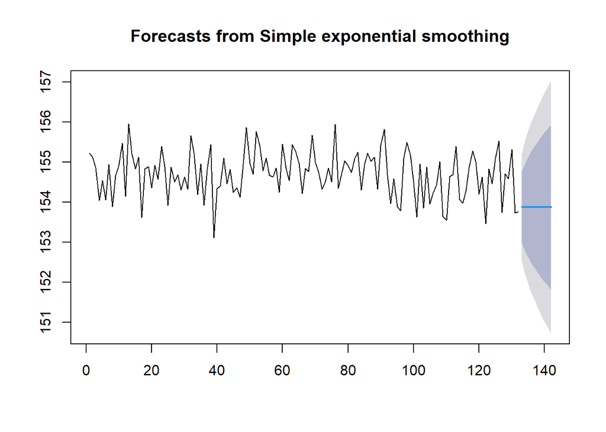

```r
ses.2<- ses(train.ts, h = 10, alpha = 0.7)
plot(ses.2)
```

```r
ses.2
```

```
##     Point Forecast    Lo 80    Hi 80    Lo 95    Hi 95
## 133       153.8734 152.9857 154.7610 152.5158 155.2309
## 134       153.8734 152.7899 154.9568 152.2163 155.5304
## 135       153.8734 152.6244 155.1224 151.9632 155.7835
## 136       153.8734 152.4783 155.2684 151.7399 156.0068
## 137       153.8734 152.3462 155.4005 151.5378 156.2089
## 138       153.8734 152.2247 155.5220 151.3519 156.3948
## 139       153.8734 152.1115 155.6352 151.1788 156.5679
## 140       153.8734 152.0051 155.7416 151.0161 156.7306
## 141       153.8734 151.9045 155.8422 150.8623 156.8844
## 142       153.8734 151.8088 155.9379 150.7159 157.0308
```

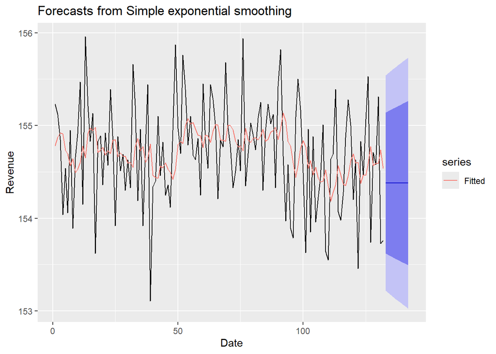

```r
autoplot(ses.1) +
  autolayer(fitted(ses.1), series="Fitted") +
  ylab("Revenue") + xlab("Date")
```

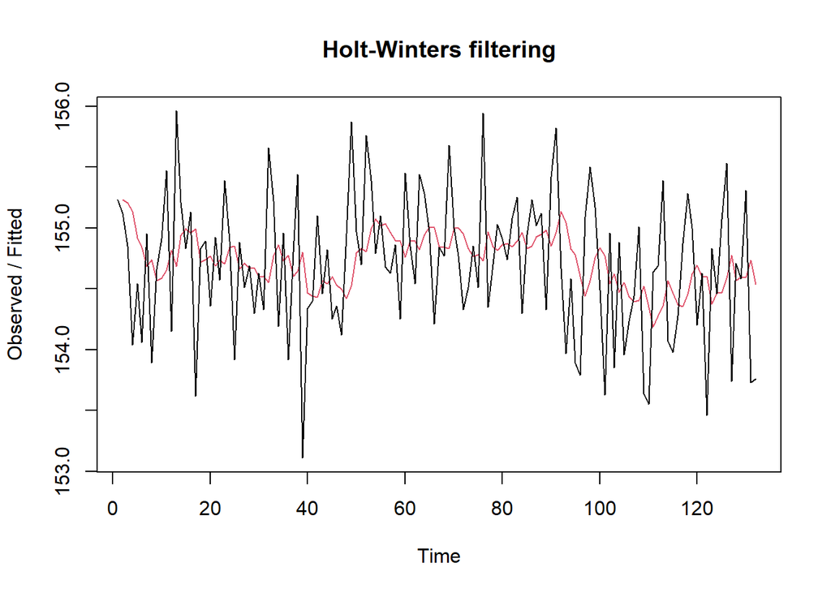

```r
#Cara 2 (fungsi Holtwinter)
ses1<- HoltWinters(train.ts, gamma = FALSE, beta = FALSE, alpha = 0.2)
plot(ses1)
```

```r
#ramalan
ramalan1<- forecast(ses1, h=10)
ramalan1
```

```
##     Point Forecast    Lo 80    Hi 80    Lo 95    Hi 95
## 133       154.3801 153.6178 155.1423 153.2143 155.5458
## 134       154.3801 153.6027 155.1574 153.1912 155.5689
## 135       154.3801 153.5879 155.1722 153.1686 155.5915
## 136       154.3801 153.5734 155.1867 153.1464 155.6138
## 137       154.3801 153.5591 155.2010 153.1245 155.6356
## 138       154.3801 153.5451 155.2150 153.1031 155.6571
## 139       154.3801 153.5313 155.2288 153.0819 155.6782
## 140       154.3801 153.5177 155.2424 153.0612 155.6989
## 141       154.3801 153.5043 155.2558 153.0407 155.7194
## 142       154.3801 153.4911 155.2690 153.0206 155.7395
```

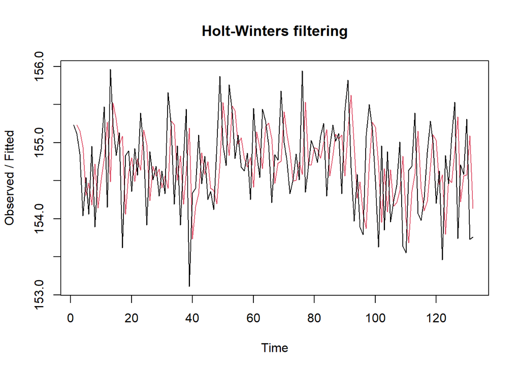

```r
ses2<- HoltWinters(train.ts, gamma = FALSE, beta = FALSE, alpha = 0.7)
plot(ses2)
```

```r
#ramalan
ramalan2<- forecast(ses2, h=10)
ramalan2
```

```
##     Point Forecast    Lo 80    Hi 80    Lo 95    Hi 95
## 133       153.8734 152.9859 154.7608 152.5161 155.2306
## 134       153.8734 152.7901 154.9566 152.2166 155.5301
## 135       153.8734 152.6246 155.1221 151.9635 155.7832
## 136       153.8734 152.4786 155.2681 151.7402 156.0065
## 137       153.8734 152.3465 155.4002 151.5382 156.2085
## 138       153.8734 152.2250 155.5217 151.3523 156.3944
## 139       153.8734 152.1118 155.6349 151.1793 156.5674
## 140       153.8734 152.0054 155.7413 151.0166 156.7301
## 141       153.8734 151.9049 155.8418 150.8628 156.8839
## 142       153.8734 151.8092 155.9375 150.7164 157.0303
```

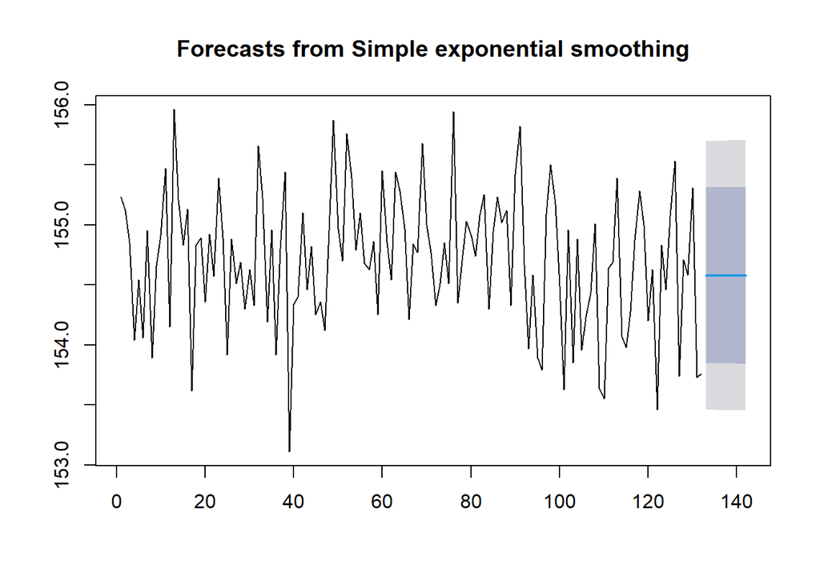

```r
#SES
ses.opt <- ses(train.ts, h = 10, alpha = NULL)
plot(ses.opt)
```